# TMA4268 Statistical Learning

Module 6: Solution sketches

Sara Martino, Stefanie Muff, Kenneth Aase

Department of Mathematical Sciences, NTNU

February 19, 2025

# 1

For the least square estimator, the solution can be found [here](https://en.wikipedia.org/wiki/Proofs_involving_ordinary_least_squares#Least_squares_estimator_for_%CE%B2).

For the maximum likelihood estimator, the solution can be found [here](https://en.wikipedia.org/wiki/Proofs_involving_ordinary_least_squares#Maximum_likelihood_approach).

# 2

```r
library(ISLR) # Package with data for an Introduction to Statistical
# Learning with Applications in R
```

```r
# Load Credit dataset
data(Credit)

# Check column names
names(Credit)
```

```
##  [1] "ID"        "Income"    "Limit"     "Rating"    "Cards"     "Age"
##  [7] "Education" "Gender"    "Student"   "Married"   "Ethnicity" "Balance"
```

```r
# Check dataset shape
dim(Credit)
```

```
## [1] 400  12
```

```r
head(Credit)
```

```
##   ID  Income Limit Rating Cards Age Education Gender Student Married Ethnicity
## 1  1  14.891  3606    283     2  34        11   Male      No     Yes Caucasian
## 2  2 106.025  6645    483     3  82        15 Female     Yes     Yes     Asian
## 3  3 104.593  7075    514     4  71        11   Male      No      No     Asian
## 4  4 148.924  9504    681     3  36        11 Female      No      No     Asian
## 5  5  55.882  4897    357     2  68        16   Male      No     Yes Caucasian
## 6  6  80.180  8047    569     4  77        10   Male      No      No Caucasian
##   Balance
## 1     333
## 2     903
## 3     580
## 4     964
## 5     331
## 6    1151
```

```r
# Select variable to plot
vars <- c("Balance", "Age", "Cards", "Education", "Income", "Limit", "Rating")
pairwise_scatter_data <- Credit[, vars]
```

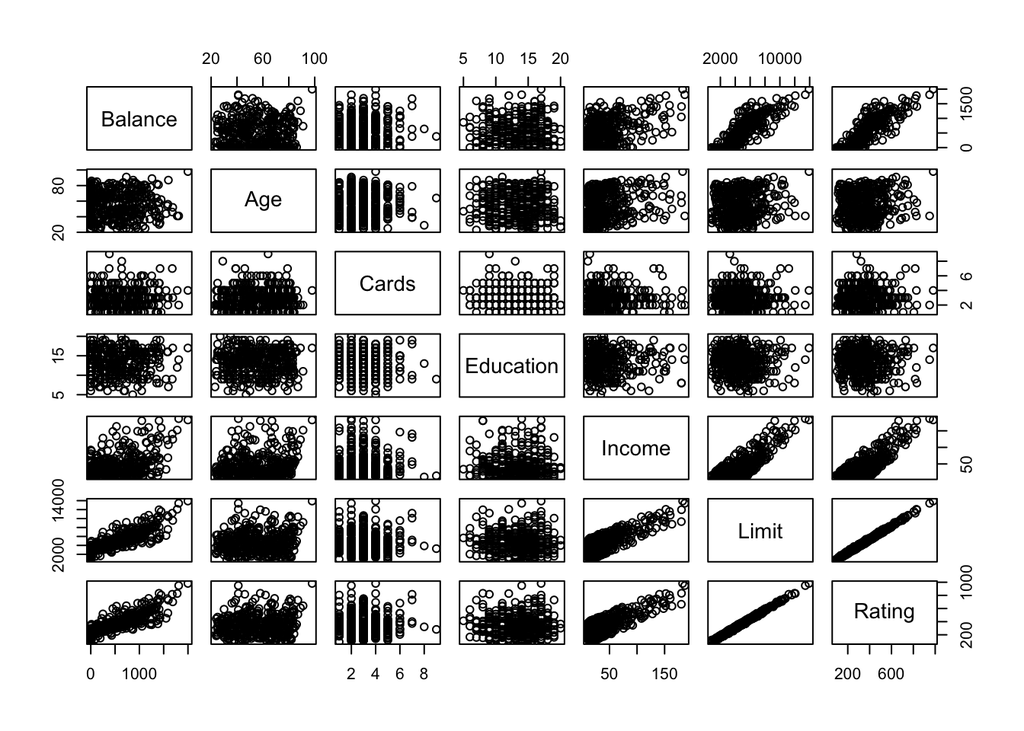

```r
# Simplest possible pairwise scatter plot
pairs(pairwise_scatter_data)
```

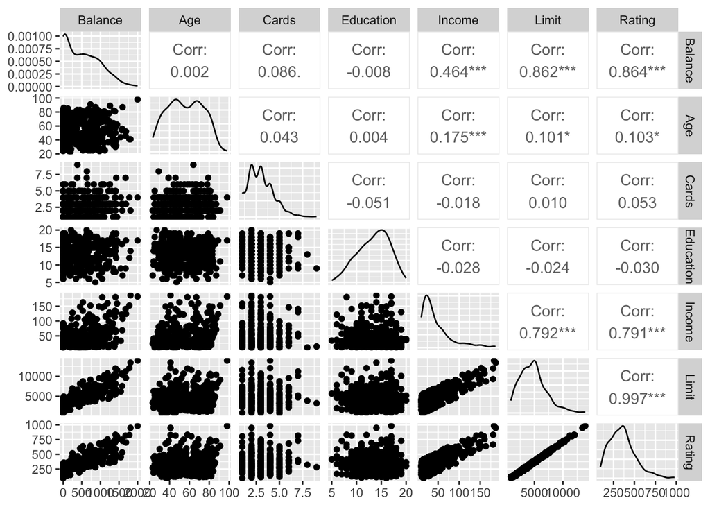

```r
# More interesting but slower pairwise plot from package GGally
library(GGally)
ggpairs(data = pairwise_scatter_data)
```

Check [here](https://tgmstat.wordpress.com/2013/11/13/plot-matrix-with-the-r-package-ggally/) for a quick guide on getting started to `ggpairs`.

# 3

```r
# Exclude 'ID' column
cred_data <- subset(Credit, select = -ID)

# Counting the dummy variables as well
cred_data_number_predictors <- 11

# Take a look at the data
head(cred_data)
```

```
##    Income Limit Rating Cards Age Education Gender Student Married Ethnicity
## 1  14.891  3606    283     2  34        11   Male      No     Yes Caucasian
## 2 106.025  6645    483     3  82        15 Female     Yes     Yes     Asian
## 3 104.593  7075    514     4  71        11   Male      No      No     Asian
## 4 148.924  9504    681     3  36        11 Female      No      No     Asian
## 5  55.882  4897    357     2  68        16   Male      No     Yes Caucasian
## 6  80.180  8047    569     4  77        10   Male      No      No Caucasian
##   Balance
## 1     333
## 2     903
## 3     580
## 4     964
## 5     331
## 6    1151
```

```r
# Summary statistics
summary(cred_data)
```

```
##      Income           Limit           Rating          Cards
##  Min.   : 10.35   Min.   :  855   Min.   : 93.0   Min.   :1.000
##  1st Qu.: 21.01   1st Qu.: 3088   1st Qu.:247.2   1st Qu.:2.000
##  Median : 33.12   Median : 4622   Median :344.0   Median :3.000
##  Mean   : 45.22   Mean   : 4736   Mean   :354.9   Mean   :2.958
##  3rd Qu.: 57.47   3rd Qu.: 5873   3rd Qu.:437.2   3rd Qu.:4.000
##  Max.   :186.63   Max.   :13913   Max.   :982.0   Max.   :9.000
##       Age          Education        Gender    Student   Married
##  Min.   :23.00   Min.   : 5.00    Male :193   No :360   No :155
##  1st Qu.:41.75   1st Qu.:11.00   Female:207   Yes: 40   Yes:245
##  Median :56.00   Median :14.00
##  Mean   :55.67   Mean   :13.45
##  3rd Qu.:70.00   3rd Qu.:16.00
##  Max.   :98.00   Max.   :20.00
##             Ethnicity      Balance
##  African American: 99   Min.   :   0.00
##  Asian           :102   1st Qu.:  68.75
##  Caucasian       :199   Median : 459.50
##                         Mean   : 520.01
##                         3rd Qu.: 863.00
##                         Max.   :1999.00
```

```r
# Create train and test set indexes
set.seed(1)
train_perc <- 0.75
cred_data_train_index <- sample(
  nrow(cred_data),
  round(nrow(cred_data) * train_perc))
# Create train and test set
cred_data_train <- cred_data[cred_data_train_index, ]
cred_data_test <- cred_data[-cred_data_train_index, ]
```

```r
library(leaps)

# Perform best subset selection using all the predictors and the training data
best_subset_method <- regsubsets(Balance ~ .,
                                 data = cred_data_train,
                                 nvmax = cred_data_number_predictors)

# Save summary obj
best_subset_method_summary <- summary(best_subset_method)
```

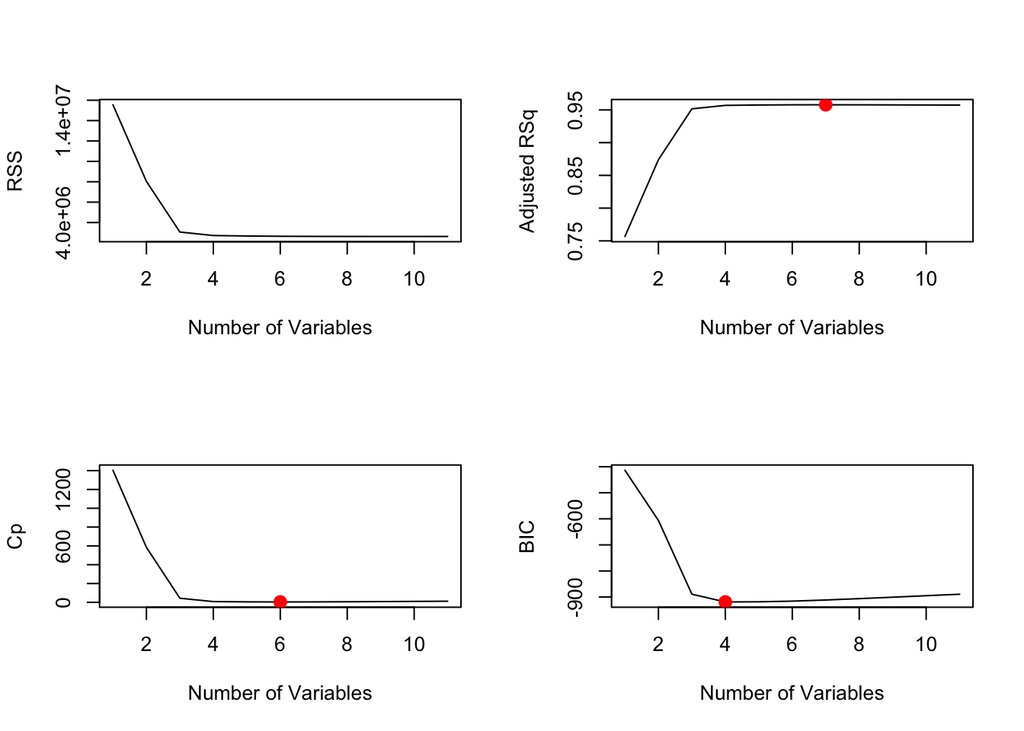

```r
# Plot RSS, Adjusted R^2, C_p and BIC

par(mfrow = c(2, 2))
plot(best_subset_method_summary$rss,
     xlab = "Number of Variables",
     ylab = "RSS",
     type = "l")

plot(best_subset_method_summary$adjr2,
     xlab = "Number of Variables",
     ylab = "Adjusted RSq",
     type = "l")

bsm_best_adjr2 <- which.max(best_subset_method_summary$adjr2)

points(bsm_best_adjr2,
       best_subset_method_summary$adjr2[bsm_best_adjr2],
       col = "red",
       cex = 2,
       pch = 20)

plot(best_subset_method_summary$cp,
     xlab = "Number of Variables",
     ylab = "Cp",
     type = "l")

bsm_best_cp <- which.min(best_subset_method_summary$cp)

points(bsm_best_cp,
       best_subset_method_summary$cp[bsm_best_cp],
       col = "red",
       cex = 2,
       pch = 20)

bsm_best_bic <- which.min(best_subset_method_summary$bic)

plot(best_subset_method_summary$bic,
     xlab = "Number of Variables",
     ylab = "BIC",
     type = "l")

points(bsm_best_bic,
       best_subset_method_summary$bic[bsm_best_bic],
       col = "red",
       cex = 2,
       pch = 20)
```

```r
# Create a prediction function to make predictions
# for regsubsets with id predictors included
predict.regsubsets <- function(object, newdata, id, ...) {
  form <- as.formula(object$call[[2]])
  mat <- model.matrix(form, newdata)
  coefi <- coef(object, id = id)
  xvars <- names(coefi)
  mat[, xvars] %*% coefi
}

# Create indexes to divide the data between folds
k <- 10
n <- nrow(cred_data_train)
set.seed(1)
folds <- rep(seq_len(k), ceiling(n / k))[seq_len(n)][sample(n)]
cv.errors <-
  matrix(NA,
         nrow = k,
         ncol = cred_data_number_predictors,
         dimnames = list(NULL, paste(1:cred_data_number_predictors)))

# Perform CV
for (j in seq_len(k)) {
  best_subset_method <- regsubsets(Balance ~ .,
                                   data = cred_data_train[folds != j, ],
                                   nvmax = cred_data_number_predictors)
  for (i in seq_len(cred_data_number_predictors)) {
    pred <- predict(best_subset_method,
                    cred_data_train[folds == j, ],
                    id = i)
    cv.errors[j, i] <- mean((cred_data_train$Balance[folds == j] - pred)^2)
  }
}

# Compute mean cv errors for each model size
mean.cv.errors <- apply(cv.errors, 2, mean)
mean.cv.errors
```

```
##         1         2         3         4         5         6         7         8
## 53156.673 28772.729 10801.110  9392.796  9408.446  9424.011  9542.508  9616.764
##         9        10        11
##  9609.772  9645.259  9669.566
```

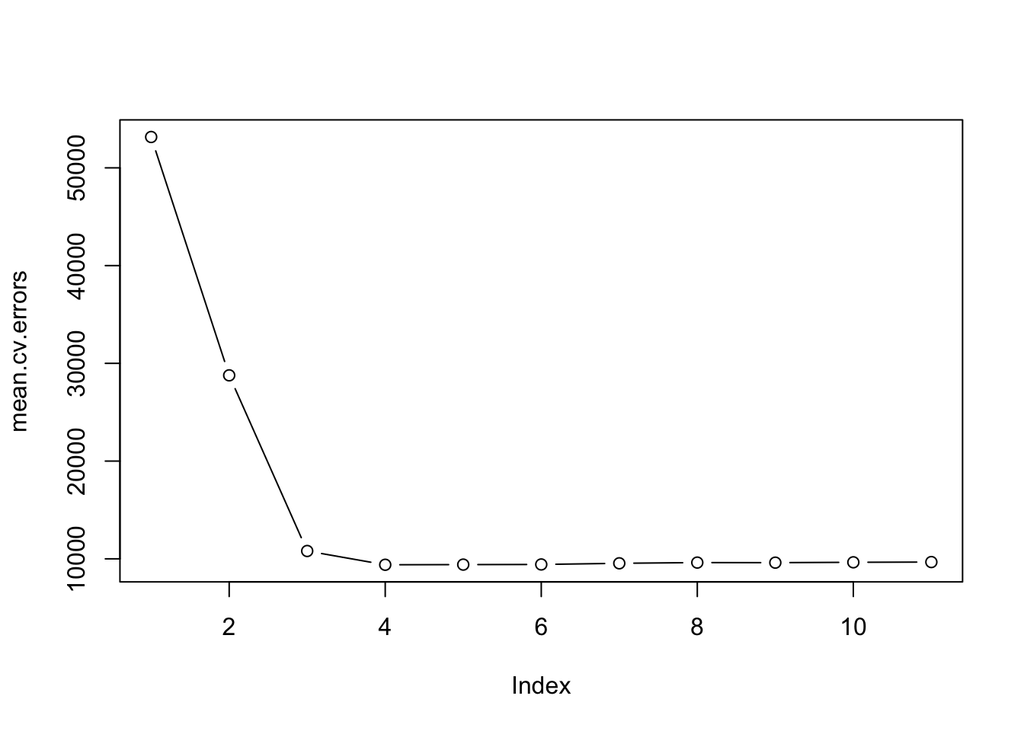

```r
# Plot the mean cv errors
par(mfrow = c(1, 1))
plot(mean.cv.errors, type = "b")
```

```r
# Fit the selected model using the whole training data
# and compute test error

# models selected
number_predictors_selected <- 4

# Create info for lm call
variables <- names(coef(best_subset_method, id = number_predictors_selected))
variables <- variables[!variables %in% "(Intercept)"]
bsm_formula <- as.formula(best_subset_method$call[[2]])
bsm_design_matrix <- model.matrix(bsm_formula, cred_data_train)[, variables]
bsm_data_train <- data.frame(Balance = cred_data_train$Balance,
                             bsm_design_matrix)

# Fit a standard linear model using only the selected
# predictors on the training data
model_best_subset_method <- lm(formula = bsm_formula, bsm_data_train)
summary(model_best_subset_method)
```

```
##
## Call:
## lm(formula = bsm_formula, data = bsm_data_train)
##
## Residuals:
##     Min      1Q  Median      3Q     Max
## -160.26  -76.81  -11.21   48.15  350.49
##
## Coefficients:
##               Estimate Std. Error t value Pr(>|t|)
## (Intercept) -5.216e+02  1.758e+01 -29.670  < 2e-16 ***
## Income      -7.856e+00  2.651e-01 -29.627  < 2e-16 ***
## Limit        2.706e-01  4.001e-03  67.622  < 2e-16 ***
## Cards        2.426e+01  3.981e+00   6.094 3.43e-09 ***
## StudentYes   4.196e+02  1.782e+01  23.542  < 2e-16 ***
## ---
## Signif. codes:  0 '***' 0.001 '**' 0.01 '*' 0.05 '.' 0.1 ' ' 1
##
## Residual standard error: 96.14 on 295 degrees of freedom
## Multiple R-squared:  0.9575, Adjusted R-squared:  0.9569
## F-statistic:  1661 on 4 and 295 DF,  p-value: < 2.2e-16
```

```r
# Make predictions on the test set
bsm_design_matrix_test <- model.matrix(bsm_formula, cred_data_test)[, variables]
bsm_preds <- predict(object = model_best_subset_method, newdata = as.data.frame(bsm_design_matrix_test))

# Compute test squared errors
bsm_squared_errors <- (cred_data_test$Balance - bsm_preds)^2
squared_errors <- data.frame(bsm_squared_errors = bsm_squared_errors)


# test MSE
mean(bsm_squared_errors)
```

```
## [1] 12243.75
```

# 4

Similar analysis as previous exercise, simply replace Best Subset Selection (`best_subset_method <- regsubsets(Balance ~ ., cred_data, nvmax = cred_data_number_predictors)`) by Forward Stepwise Selection (`regfit.fwd <- regsubsets(Balance ~ ., cred_data, nvmax = cred_data_number_predictors, method = "forward")`), Backward Stepwise Selection (`regfit.fwd <- regsubsets(Balance ~ ., cred_data, nvmax = cred_data_number_predictors, method = "backward")`) and Hybrid Stepwise Selection (`regfit.fwd <- regsubsets(Balance ~ ., cred_data, nvmax = cred_data_number_predictors, method = "seqrep")`)

# 5

```r
library(glmnet) # Package Lasso and Elastic-Net Regularized
# Generalized Linear Models
```

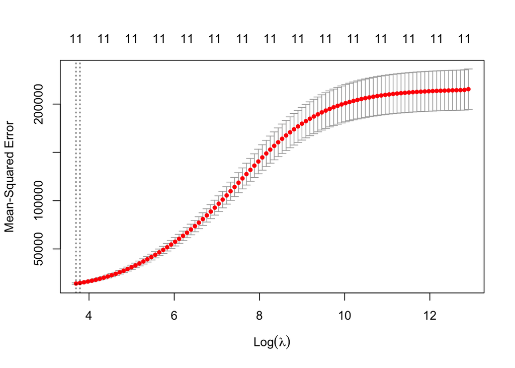

```r
x_train <- model.matrix(Balance ~ ., cred_data_train)[, -1]
y_train <- cred_data_train$Balance

x_test <- model.matrix(Balance ~ ., cred_data_test)[, -1]
y_test <- cred_data_test$Balance

# `alpha=0` is the ridge penalty.
ridge_mod <- glmnet(x_train, y_train, alpha = 0)

set.seed(1)
cv.out <- cv.glmnet(x_train, y_train, alpha = 0)
plot(cv.out)
```

```r
best_lambda_ridge <- cv.out$lambda.min
best_lambda_ridge
```

```
## [1] 40.24862
```

```r
ridge_preds <- predict(ridge_mod, s = best_lambda_ridge, newx = x_test)
ridge_square_errors <- as.numeric((ridge_preds - y_test)^2)
squared_errors <- data.frame(ridge_square_errors = ridge_square_errors,
                             squared_errors)
```

# 6

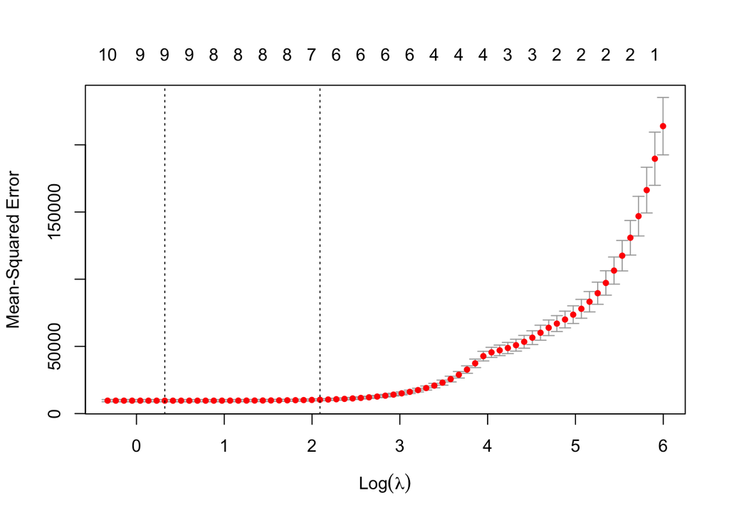

```r
# `alpha=1` is the lasso penalty.
lasso_mod <- glmnet(x_train, y_train, alpha = 1)

set.seed(1)
cv.out <- cv.glmnet(x_train, y_train, alpha = 1)
plot(cv.out)
```

```r
best_lambda_lasso <- cv.out$lambda.min
best_lambda_lasso
```

```
## [1] 1.380717
```

```r
lasso_preds <- predict(lasso_mod, s = best_lambda_lasso, newx = x_test)
lasso_square_errors <- as.numeric((lasso_preds - y_test)^2)
squared_errors <- data.frame(lasso_square_errors = lasso_square_errors,
                             squared_errors)
```

# 7

```r
x <- model.matrix(Balance ~ ., cred_data)[, -1]

cred_pca <- prcomp(x, center = TRUE, scale. = TRUE)

print(cred_pca)
```

```
## Standard deviations (1, .., p=11):
##  [1] 1.66007642 1.26685832 1.05356810 1.04926273 1.00322222 0.98576693
##  [7] 0.97830708 0.90714714 0.63722533 0.51174012 0.04617646
##
## Rotation (n x k) = (11 x 11):
##                             PC1          PC2          PC3           PC4
## Income             -0.542206953  0.029036783 -0.033270648 -6.564051e-05
## Limit              -0.586332930  0.017502630 -0.024351723  4.678929e-02
## Rating             -0.586751867  0.014971105 -0.004630758  3.687909e-02
## Cards              -0.019086978 -0.008549632  0.479005750 -2.720228e-01
## Age                -0.122783390 -0.071116603  0.107188498 -4.787335e-01
## Education           0.026797471  0.096557225 -0.475418336  1.990653e-01
## GenderFemale       -0.002519860  0.052811098 -0.334014058 -4.207748e-02
## StudentYes          0.002276904  0.125422970 -0.618650527 -2.963169e-01
## MarriedYes         -0.026218561  0.094278214  0.125718135  7.389864e-01
## EthnicityAsian      0.032769895  0.696759512  0.105703127  6.686132e-03
## EthnicityCaucasian -0.004070799 -0.686505857 -0.100240068  1.338718e-01
##                            PC5         PC6         PC7         PC8          PC9
## Income             -0.02816858 -0.02297156 -0.04086888 -0.03502243 -0.016018928
## Limit               0.02393728 -0.06109959  0.02753603  0.07998103 -0.010697575
## Rating              0.03044748 -0.04901285  0.06298342  0.07474080 -0.005366527
## Cards               0.07450235  0.28313105  0.77070237  0.10917776  0.005357720
## Age                -0.29468570  0.58353604 -0.35860755 -0.41270188 -0.048994454
## Education          -0.58335540  0.40244676  0.21601791  0.41794930 -0.021973159
## GenderFemale        0.74620452  0.51375214 -0.10203846  0.22746095  0.014513597
## StudentYes          0.05874438 -0.20236658  0.42777847 -0.53366278  0.022068488
## MarriedYes          0.04850438  0.32419986  0.13571418 -0.53676497  0.119017609
## EthnicityAsian      0.02125450 -0.01284830 -0.04334986 -0.01824866 -0.706522468
## EthnicityCaucasian  0.04400214  0.02306227  0.10322555 -0.06987098 -0.694731116
##                            PC10          PC11
## Income              0.836411394  0.0017092799
## Limit              -0.379489022  0.7053633132
## Rating             -0.373834509 -0.7081335719
## Cards               0.059511066  0.0305564113
## Age                -0.102540342  0.0005901693
## Education           0.014172918 -0.0036133922
## GenderFemale        0.027300122  0.0001327203
## StudentYes         -0.032119354  0.0044219212
## MarriedYes         -0.018248384  0.0051766487
## EthnicityAsian     -0.014783578 -0.0035849536
## EthnicityCaucasian  0.008145839 -0.0004464620
```

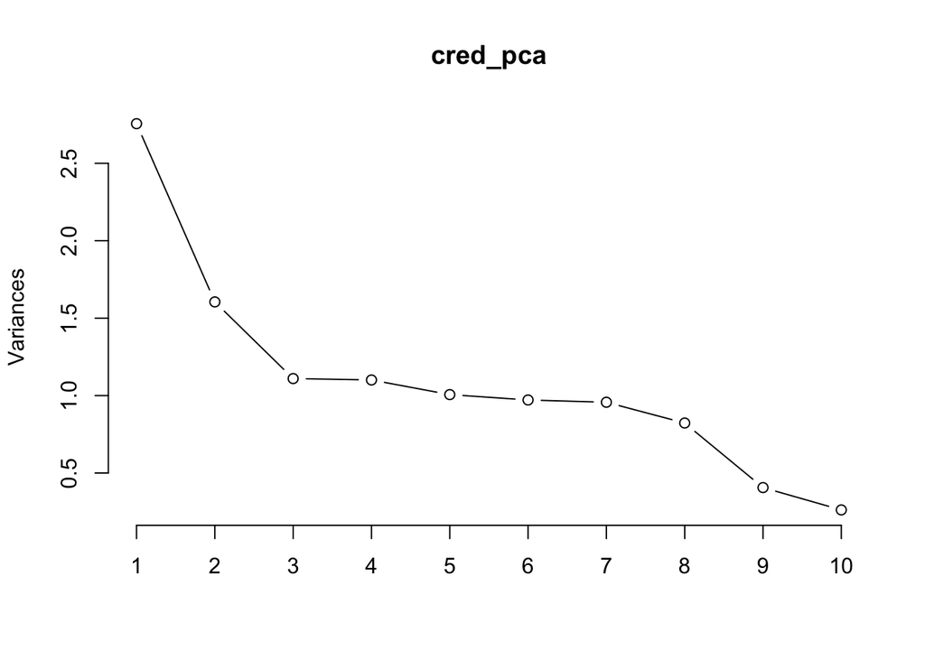

```r
plot(cred_pca, type = "l")
```

```r
summary(cred_pca)
```

```
## Importance of components:
##                           PC1    PC2    PC3    PC4    PC5     PC6     PC7
## Standard deviation     1.6601 1.2669 1.0536 1.0493 1.0032 0.98577 0.97831
## Proportion of Variance 0.2505 0.1459 0.1009 0.1001 0.0915 0.08834 0.08701
## Cumulative Proportion  0.2505 0.3964 0.4973 0.5974 0.6889 0.77727 0.86427
##                            PC8     PC9    PC10    PC11
## Standard deviation     0.90715 0.63723 0.51174 0.04618
## Proportion of Variance 0.07481 0.03691 0.02381 0.00019
## Cumulative Proportion  0.93908 0.97600 0.99981 1.00000
```

The first PC explains about $25\%$ of the variability in the data. Then the second PC explains an extra $15\%$ of the variability in the data. From the third PC until $8$th PC the extra variability explained per PC varies between $7.5\%$ to $10\%$, dropping to $3.6\%$ on the $9$th PCA. So I would likely use $8$ PCs for the `Credit` dataset.

# 8

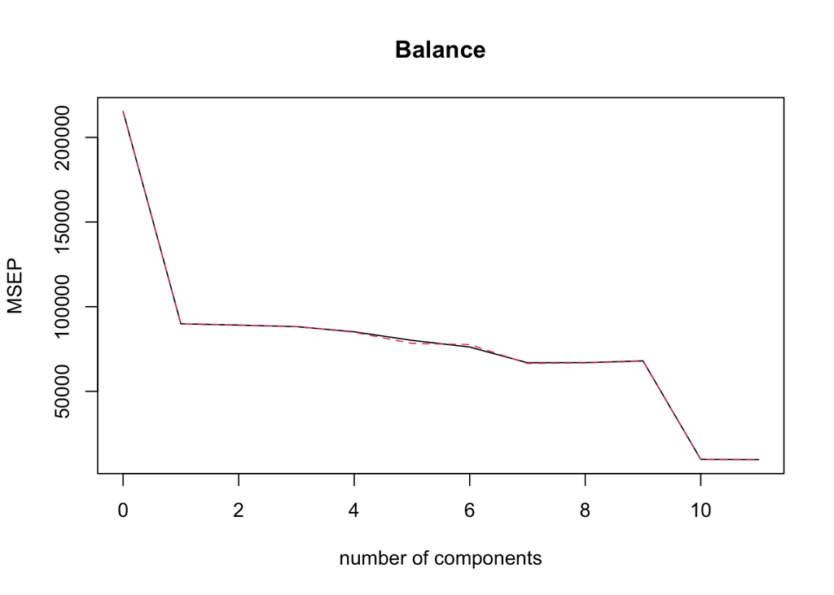

```r
library(pls)

set.seed(1)

pcr_model <- pcr(Balance ~ .,
                 data = cred_data_train,
                 scale = TRUE,
                 validation = "CV")
validationplot(pcr_model, val.type = "MSEP")
```

```r
pcr_preds <- predict(pcr_model, cred_data_test, ncomp = 10)
pcr_square_errors <- as.numeric((pcr_preds - cred_data_test$Balance)^2)
squared_errors <- data.frame(pcr_square_errors = pcr_square_errors,
                             squared_errors)
mean(pcr_square_errors)
```

```
## [1] 11578.1
```

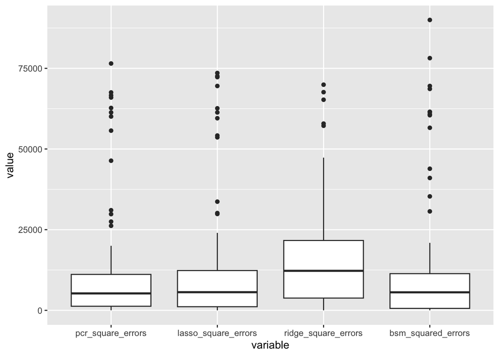

```r
library(ggplot2)
library(reshape2)
ggplot(melt(squared_errors)) +
  geom_boxplot(aes(variable, value))
```

# 9

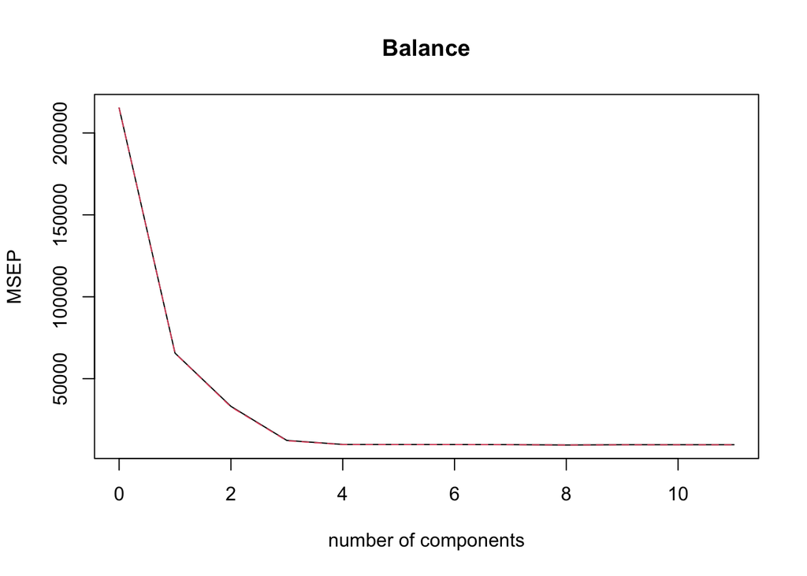

```r
library(pls)

set.seed(1)

plsr_model <- plsr(Balance ~ .,
                   data = cred_data_train,
                   scale = TRUE,
                   validation = "CV")
validationplot(plsr_model, val.type = "MSEP")
```

```r
plsr_preds <- predict(plsr_model, cred_data_test, ncomp = 3)
plsr_square_errors <- as.numeric((plsr_preds - cred_data_test$Balance)^2)
squared_errors <- data.frame(plsr_square_errors = plsr_square_errors,
                             squared_errors)
mean(plsr_square_errors)
```

```
## [1] 12476.32
```

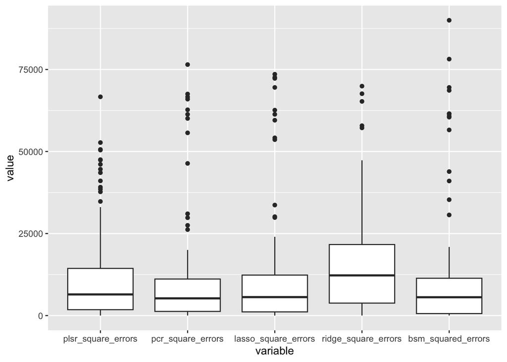

```r
ggplot(melt(squared_errors)) +
  geom_boxplot(aes(variable, value))
```

```r
colMeans(squared_errors)
```

```
##  plsr_square_errors   pcr_square_errors lasso_square_errors ridge_square_errors
##            12476.32            11578.10            12077.15            15742.83
##  bsm_squared_errors
##            12243.75
```